# prob5cp1

Matheus Freitas

26 de julho de 2018

Nessa análise, utilizaremos dados que descrevem 5000 encontros relâmpagos *(speed dating)* de 4 minutos envolvendo 310 jovens americanos. Os participantes tinham vários encontros de 4 minutos por noite. Os dados e o seu significado foram retirados [deste](https://github.com/nazareno/ciencia-de-dados-1/tree/master/5-regressao/speed-dating) repositório.

## Qual a relação entre o like e o quão atraente a pessoa 1 achou a pessoa 2?

Para essa análise, iremos ocultar os casos em que a pessoa 1 optou por não responder as perguntas.  
Em todos os modelos abaixo iremos utilizar como variável dependente o *like* e *attr* como variável independente, o valor que iremos observar será o da coluna **estimate** que mostra o quanto as variáveis independentes influenciam a variável dependente.

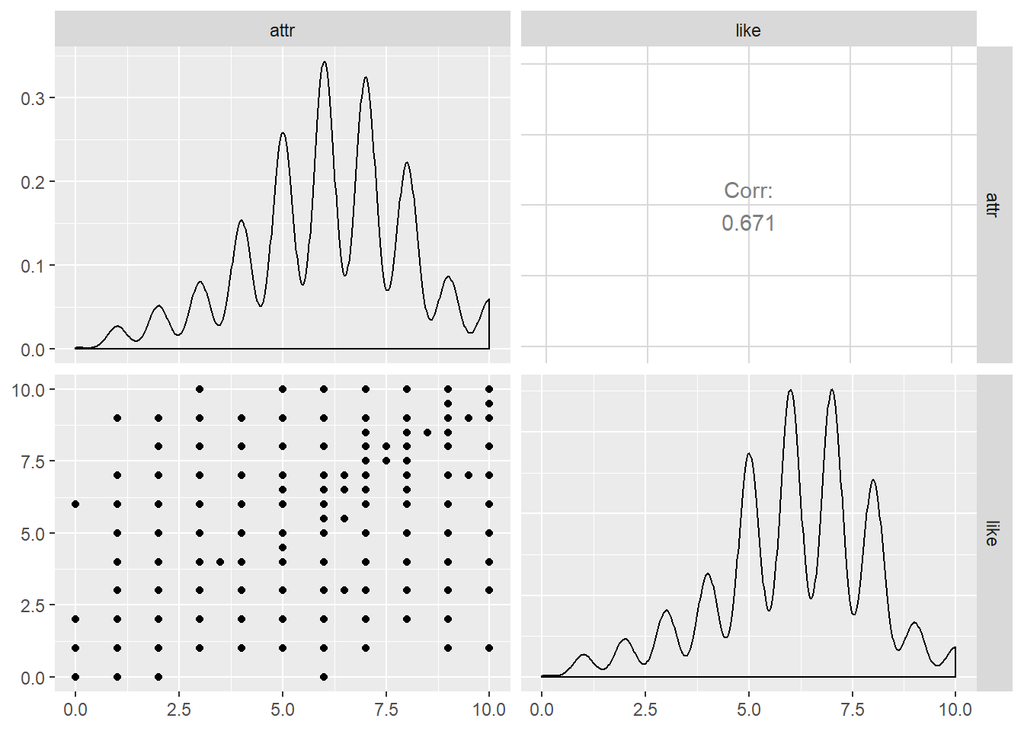

```r
ambos_sexos = speed_dating %>%
  select(like, attr, gender) %>%
  na.omit()

modelo_ambos_sexos = lm(like ~ attr,
                        data = ambos_sexos)
ambos_sexos %>%
  select(attr, like) %>%
  ggpairs()
```

```r
tidy(modelo_ambos_sexos)
```

```
##          term  estimate  std.error statistic       p.value
## 1 (Intercept) 2.1825407 0.06487213  33.64373 6.484123e-223
## 2        attr 0.6378654 0.01018173  62.64806  0.000000e+00
```

```r
glance(modelo_ambos_sexos)
```

```
##   r.squared adj.r.squared   sigma statistic p.value df    logLik      AIC
## 1  0.450721     0.4506062 1.37309  3924.779       0  2 -8305.772 16617.54
##        BIC deviance df.residual
## 1 16636.96 9017.759        4783
```

Utilizando esse modelo de regressão linear simples, podemos observar que a correlação entre like e o quão atraente a pessoa 1 achou a pessoa dois é de 0.671, ou seja, essa variável influencia positivamente o like. No entanto, não chega a ser uma varável muito forte. Além disso, o R² é de 0.45, ou seja, esse modelo não é de fato bom para explicar esses valores.

## Essa relação muda de acordo com o sexo?

```r
feminino = ambos_sexos %>%
  filter(gender == 0)

modelo_feminino = lm(like ~ attr,
                     data = feminino)

tidy(modelo_feminino)
```

```
##          term  estimate  std.error statistic       p.value
## 1 (Intercept) 2.0635940 0.08864880  23.27831 3.444874e-108
## 2        attr 0.6574372 0.01446505  45.45004  0.000000e+00
```

```r
glance(modelo_feminino)
```

```
##   r.squared adj.r.squared    sigma statistic p.value df   logLik     AIC
## 1 0.4639215     0.4636969 1.411335  2065.706       0  2 -4211.94 8429.88
##        BIC deviance df.residual
## 1 8447.216 4754.584        2387
```

```r
masculino = ambos_sexos %>%
  filter(gender == 1)

modelo_masculino = lm(like ~ attr,
                      data = masculino)
tidy(modelo_masculino)
```

```
##          term  estimate  std.error statistic       p.value
## 1 (Intercept) 2.3355204 0.09656083  24.18704 8.166189e-116
## 2        attr 0.6145953 0.01461986  42.03839 1.003904e-289
```

```r
glance(modelo_masculino)
```

```
##   r.squared adj.r.squared    sigma statistic       p.value df    logLik
## 1 0.4246889     0.4244485 1.333158  1767.227 1.003904e-289  2 -4087.747
##        AIC      BIC deviance df.residual
## 1 8181.494 8198.839  4254.88        2394
```

*Modelo feminino: Possui um **estimate** na linha de* attr* de 0.65, logo podemos afirmar que este possui influência positiva no modelo mas não muito forte, como podemos observar no **r.squared**, que está muito abaixo de 1, ou seja, nos diz que esse modelo não é muito representativo para explicar esses valores.  
*Modelo masculino: Possui um **estimate** na linha de* attr* de 0.61, ou seja, menor que o do modelo feminino, logo podemos confirmar que para os homens dessa enquete o quão eles acham a pessoa 2 do encontro atraente influencia menos que para as mulheres. No entanto, é importante analisar que o **r.squared** é de 0.42, sendo um modelo não muito representativo para esses valores, como já tinhamos observado.